# GDP by Year

## Plotting the Graphs

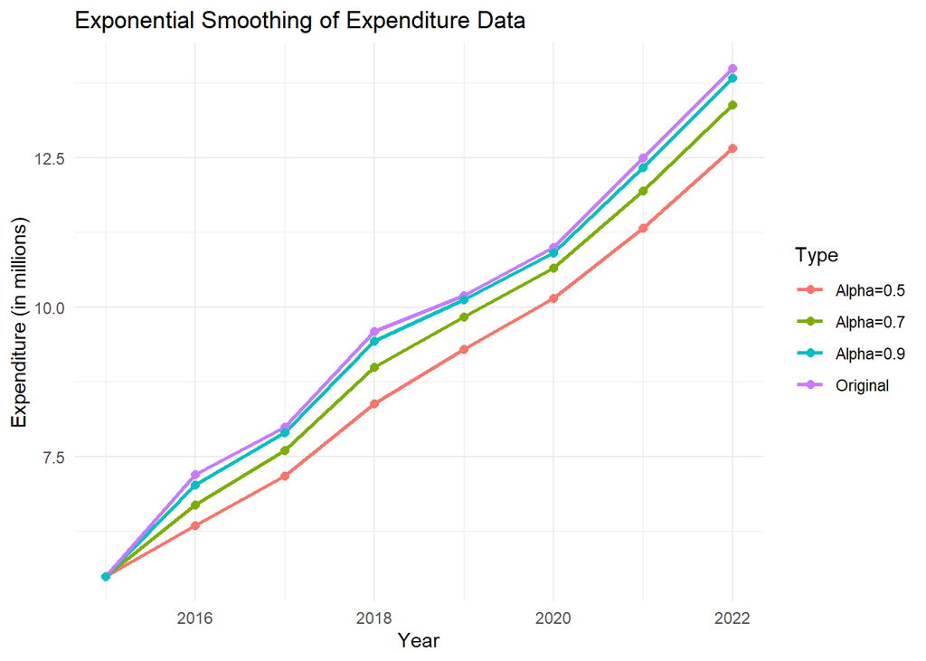

```r
#Preparing data for plotting
pd<-data.frame(Year=rep(yr,4),Expenditure=c(expn,smoothed_0_5,smoothed_0_7,smoothed_0_9),Type =rep(c("Original","Alpha=0.5","Alpha=0.7","Alpha=0.9"),each = length(yr))
)
#Plotting
ggplot(pd,aes(x=Year,y=Expenditure,color=Type))+geom_line(size=1)+geom_point(size=2)+labs(title="Exponential Smoothing of Expenditure Data",x = "Year", y = "Expenditure (in millions)")+theme_minimal()
```

#### Interpretation of the Plot

The plot shows the original expenditure data and the smoothed values obtained using exponential smoothing with three different alpha values ($\alpha = 0.5$, $\alpha = 0.7$, and $\alpha = 0.9$) from the years 2015 to 2022.

**Original Data (Purple Line)**

- The original data points are represented by the purple line. This line shows the actual expenditure values for each year from $2015$ to $2022$.

#### Alpha=0.5 (Red Line)

- The red line represents the smoothed values with $\alpha = 0.5$.
- This line is smoother and shows less responsiveness to changes in the actual data compared to higher alpha values.
- It tends to lag behind the actual values, especially in years where there is a significant change in expenditure.

#### Alpha=0.7 (Green Line)

- The green line represents the smoothed values with $\alpha = 0.7$.
- This line is more responsive to changes in the actual data compared to $\alpha = 0.5$.
- It provides a closer fit to the actual expenditure values but still shows some smoothing effect.

#### Alpha=0.9 (Blue Line)

- The blue line represents the smoothed values with $\alpha = 0.9$.
- This line is the most responsive to changes in the actual data, closely following the actual expenditure values.
- The high alpha value results in minimal smoothing, making the smoothed values very similar to the actual values.

**Higher Alpha Values**

- As the alpha value increases, the smoothed values become more responsive to the actual data, resulting in smaller forecast errors. This is evident from the blue line ($\alpha = 0.9$), which closely follows the original data points.

**Lower Alpha Values**

- Lower alpha values result in greater smoothing and less responsiveness to changes in the data. The red line ($\alpha = 0.5$) demonstrates this by showing a smoother curve that lags behind the actual expenditure values.

**Medium Alpha Values**

- The green line ($\alpha = 0.7$) provides a balance between responsiveness and smoothing, fitting the data better than the red line but not as closely as the blue line.

**Conclusion** In this case, $\alpha = 0.9$ provides the closest fit to the actual expenditure values, indicating that the recent observations have a strong influence on the future expenditures.